# diamonds

Cynthia O’Donnell

05/29/2015

# Analyzing Diamonds

```r
library(ggplot2)
data(diamonds)
summary(diamonds)
```

```
##      carat               cut        color        clarity
##  Min.   :0.2000   Fair     : 1610   D: 6775   SI1    :13065
##  1st Qu.:0.4000   Good     : 4906   E: 9797   VS2    :12258
##  Median :0.7000   Very Good:12082   F: 9542   SI2    : 9194
##  Mean   :0.7979   Premium  :13791   G:11292   VS1    : 8171
##  3rd Qu.:1.0400   Ideal    :21551   H: 8304   VVS2   : 5066
##  Max.   :5.0100                     I: 5422   VVS1   : 3655
##                                     J: 2808   (Other): 2531
##      depth           table           price             x
##  Min.   :43.00   Min.   :43.00   Min.   :  326   Min.   : 0.000
##  1st Qu.:61.00   1st Qu.:56.00   1st Qu.:  950   1st Qu.: 4.710
##  Median :61.80   Median :57.00   Median : 2401   Median : 5.700
##  Mean   :61.75   Mean   :57.46   Mean   : 3933   Mean   : 5.731
##  3rd Qu.:62.50   3rd Qu.:59.00   3rd Qu.: 5324   3rd Qu.: 6.540
##  Max.   :79.00   Max.   :95.00   Max.   :18823   Max.   :10.740
##
##        y                z
##  Min.   : 0.000   Min.   : 0.000
##  1st Qu.: 4.720   1st Qu.: 2.910
##  Median : 5.710   Median : 3.530
##  Mean   : 5.735   Mean   : 3.539
##  3rd Qu.: 6.540   3rd Qu.: 4.040
##  Max.   :58.900   Max.   :31.800
##
```

```r
str(diamonds)
```

```
## 'data.frame':    53940 obs. of  10 variables:
##  $ carat  : num  0.23 0.21 0.23 0.29 0.31 0.24 0.24 0.26 0.22 0.23 ...
##  $ cut    : Ord.factor w/ 5 levels "Fair"<"Good"<..: 5 4 2 4 2 3 3 3 1 3 ...
##  $ color  : Ord.factor w/ 7 levels "D"<"E"<"F"<"G"<..: 2 2 2 6 7 7 6 5 2 5 ...
##  $ clarity: Ord.factor w/ 8 levels "I1"<"SI2"<"SI1"<..: 2 3 5 4 2 6 7 3 4 5 ...
##  $ depth  : num  61.5 59.8 56.9 62.4 63.3 62.8 62.3 61.9 65.1 59.4 ...
##  $ table  : num  55 61 65 58 58 57 57 55 61 61 ...
##  $ price  : int  326 326 327 334 335 336 336 337 337 338 ...
##  $ x      : num  3.95 3.89 4.05 4.2 4.34 3.94 3.95 4.07 3.87 4 ...
##  $ y      : num  3.98 3.84 4.07 4.23 4.35 3.96 3.98 4.11 3.78 4.05 ...
##  $ z      : num  2.43 2.31 2.31 2.63 2.75 2.48 2.47 2.53 2.49 2.39 ...
```

```r
summary(diamonds$color)
```

```
##     D     E     F     G     H     I     J
##  6775  9797  9542 11292  8304  5422  2808
```

#### A histogram of diamond prices

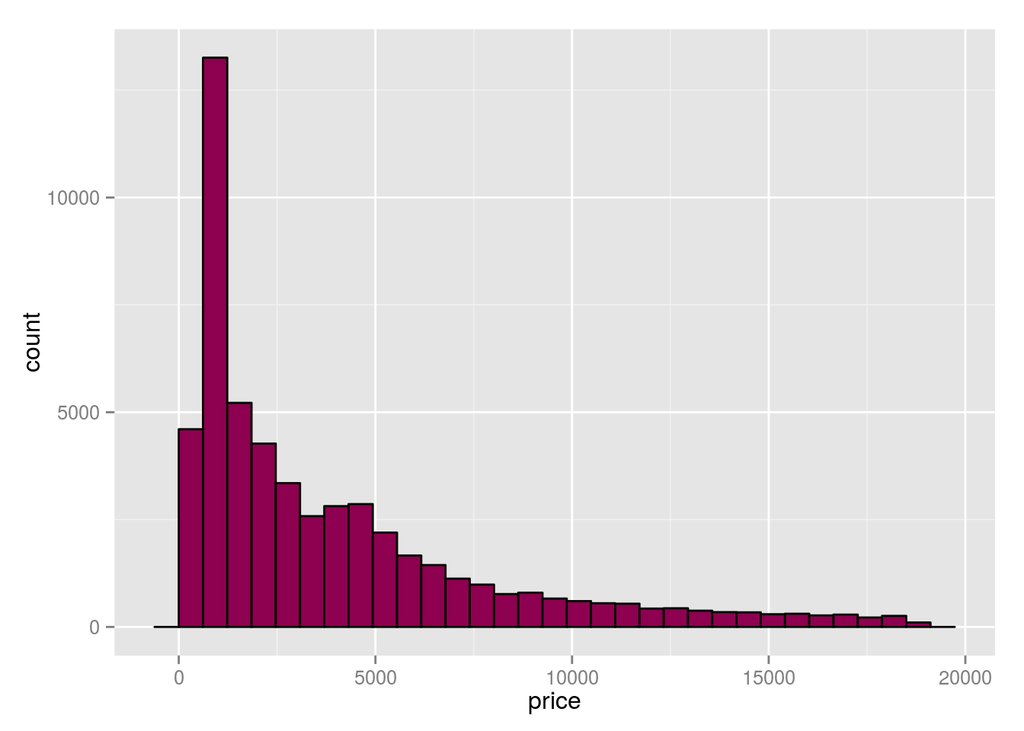

```r
summary(diamonds$price)
```

```
##    Min. 1st Qu.  Median    Mean 3rd Qu.    Max.
##     326     950    2401    3933    5324   18820
```

##### The distribution is right tailed with a median of 2401 and a mean of 3933.

```r
summary(diamonds$price < 500)
```

```
##    Mode   FALSE    TRUE    NA's
## logical   52211    1729       0
```

```r
summary(diamonds$price < 250)
```

```
##    Mode   FALSE    NA's
## logical   53940       0
```

```r
summary(diamonds$price > 15000)
```

```
##    Mode   FALSE    TRUE    NA's
## logical   52285    1655       0
```

There are no diamonds worth less than $250 and there are 1655 diamonds worth more than $15,000.

#### Let’s change the bin width and the axes

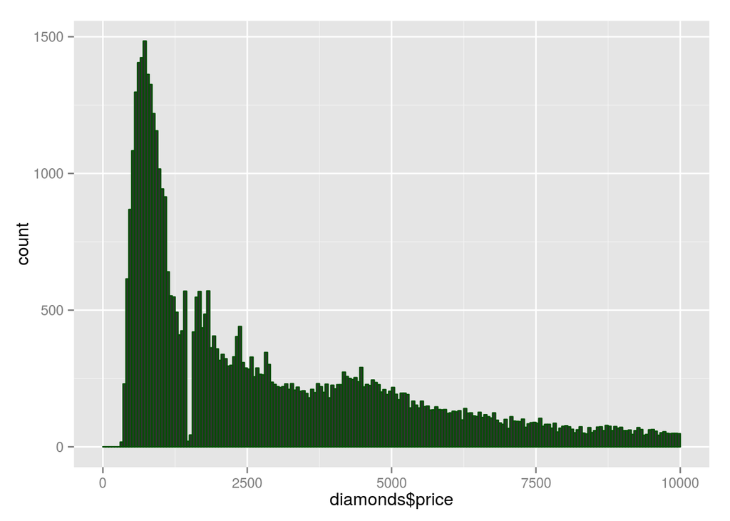

#### Facet Wrap by cut

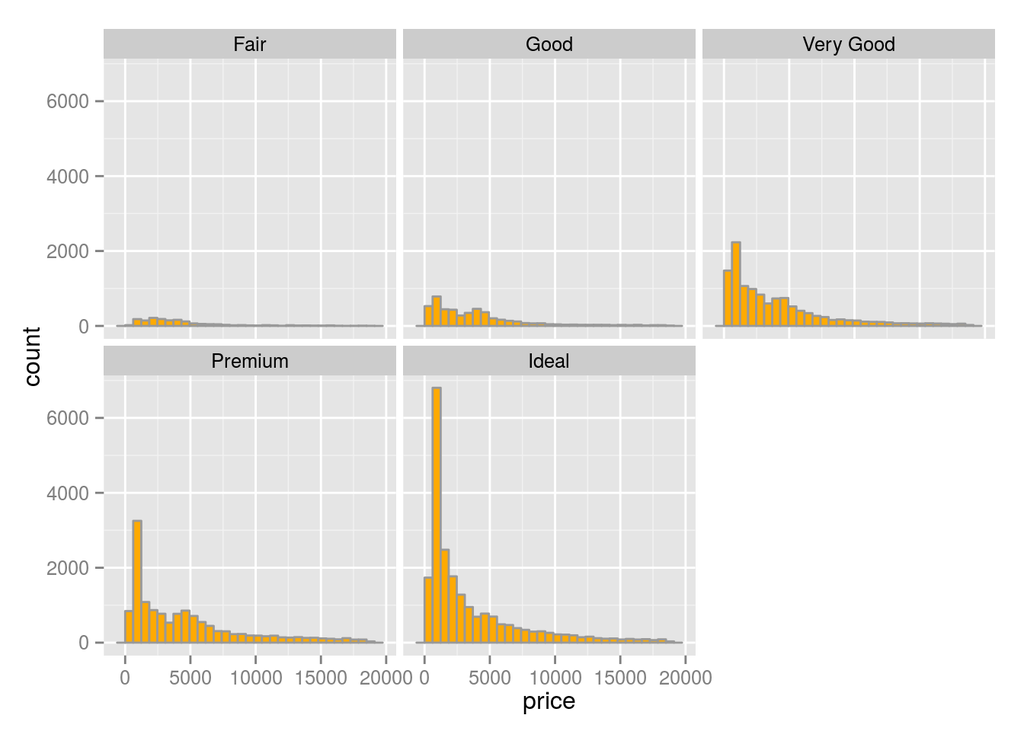

#### Which cut has the highest priced diamond?

```r
diamonds$cut[diamonds$price == max(diamonds$price)]
```

```
## [1] Premium
## Levels: Fair < Good < Very Good < Premium < Ideal
```

#### Which cut has the lowest priced diamond?

```r
diamonds$cut[diamonds$price == min(diamonds$price)]
```

```
## [1] Ideal   Premium
## Levels: Fair < Good < Very Good < Premium < Ideal
```

#### Which cut has the lowest median price?

```r
by(diamonds$price, diamonds$cut, median)
```

```
## diamonds$cut: Fair
## [1] 3282
## --------------------------------------------------------
## diamonds$cut: Good
## [1] 3050.5
## --------------------------------------------------------
## diamonds$cut: Very Good
## [1] 2648
## --------------------------------------------------------
## diamonds$cut: Premium
## [1] 3185
## --------------------------------------------------------
## diamonds$cut: Ideal
## [1] 1810
```

#### Lets look into the relative price distributions by cut again.

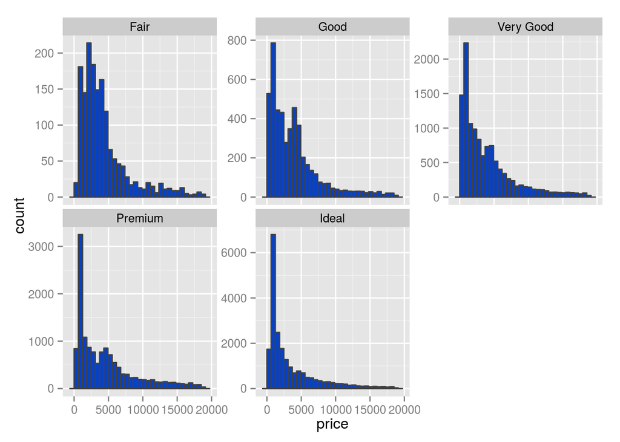

```r
qplot(x = price, data = diamonds, color=I("#414141"), fill=I("#0641c8")) +
  facet_wrap(~cut, scales="free_y")
```

##### Now the graphs indicate that the distributions are similarly distributed.

### Price Per Carat

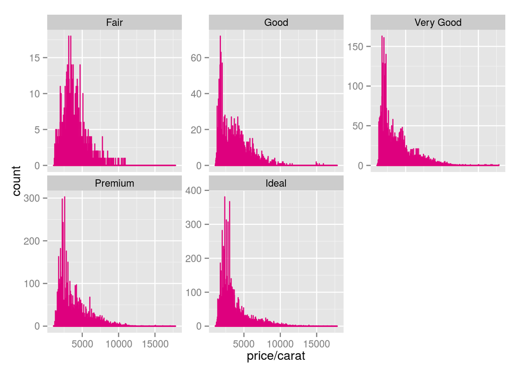

```r
qplot(x = price/carat, data = diamonds, color=I("#de007e"), fill=I("#414141"), binwidth = 10) +
  facet_wrap(~cut, scales="free_y")
```

#### Box Plot

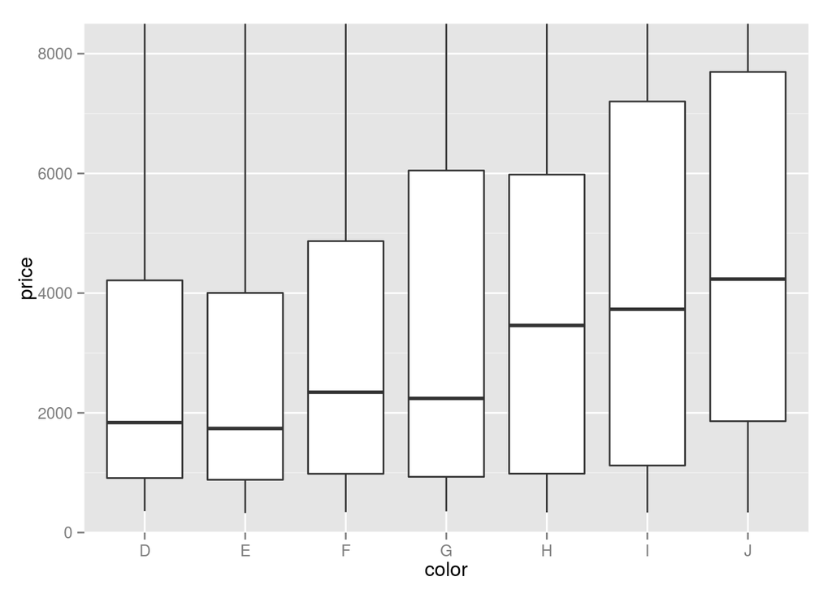

```r
qplot(x=color, y=price,
      data=diamonds,
      geom='boxplot') +
  coord_cartesian(ylim=c(0,8500))
```

#### Summarize price by color

```r
by(diamonds$price, diamonds$color, summary)
```

```
## diamonds$color: D
##    Min. 1st Qu.  Median    Mean 3rd Qu.    Max.
##     357     911    1838    3170    4214   18690
## --------------------------------------------------------
## diamonds$color: E
##    Min. 1st Qu.  Median    Mean 3rd Qu.    Max.
##     326     882    1739    3077    4003   18730
## --------------------------------------------------------
## diamonds$color: F
##    Min. 1st Qu.  Median    Mean 3rd Qu.    Max.
##     342     982    2344    3725    4868   18790
## --------------------------------------------------------
## diamonds$color: G
##    Min. 1st Qu.  Median    Mean 3rd Qu.    Max.
##     354     931    2242    3999    6048   18820
## --------------------------------------------------------
## diamonds$color: H
##    Min. 1st Qu.  Median    Mean 3rd Qu.    Max.
##     337     984    3460    4487    5980   18800
## --------------------------------------------------------
## diamonds$color: I
##    Min. 1st Qu.  Median    Mean 3rd Qu.    Max.
##     334    1120    3730    5092    7202   18820
## --------------------------------------------------------
## diamonds$color: J
##    Min. 1st Qu.  Median    Mean 3rd Qu.    Max.
##     335    1860    4234    5324    7695   18710
```

```r
7695-1860
```

```
## [1] 5835
```

```r
4214-911
```

```
## [1] 3303
```

## Bivariate Analysis

Create a scatterplot of price vs x.

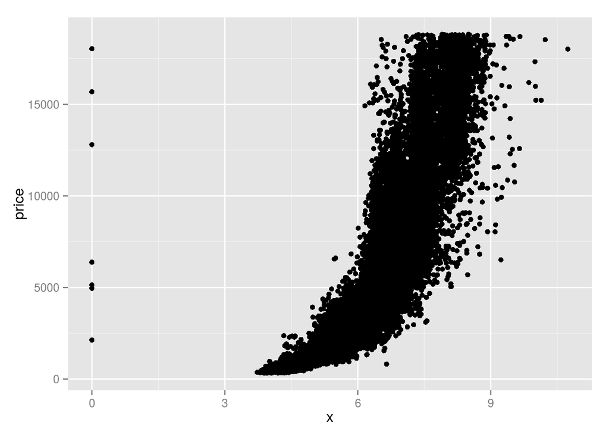

```r
ggplot(aes(x=x, y=price), data = diamonds) +
  geom_point()
```

The scatterplot has several outliers with x values of 0. Generally, as the value of x increases past 6, the price increases exponentially.

Now, I find the correlation between price and each of x, y and z.

```r
cor.test(diamonds$x, diamonds$price, method = 'pearson')
```

```
##
##  Pearson's product-moment correlation
##
## data:  diamonds$x and diamonds$price
## t = 440.1594, df = 53938, p-value < 2.2e-16
## alternative hypothesis: true correlation is not equal to 0
## 95 percent confidence interval:
##  0.8825835 0.8862594
## sample estimates:
##       cor
## 0.8844352
```

```r
cor.test(diamonds$y, diamonds$price, method = 'pearson')
```

```
##
##  Pearson's product-moment correlation
##
## data:  diamonds$y and diamonds$price
## t = 401.1415, df = 53938, p-value < 2.2e-16
## alternative hypothesis: true correlation is not equal to 0
## 95 percent confidence interval:
##  0.8632867 0.8675241
## sample estimates:
##       cor
## 0.8654209
```

```r
cor.test(diamonds$z, diamonds$price, method = 'pearson')
```

```
##
##  Pearson's product-moment correlation
##
## data:  diamonds$z and diamonds$price
## t = 393.6015, df = 53938, p-value < 2.2e-16
## alternative hypothesis: true correlation is not equal to 0
## 95 percent confidence interval:
##  0.8590541 0.8634131
## sample estimates:
##       cor
## 0.8612494
```

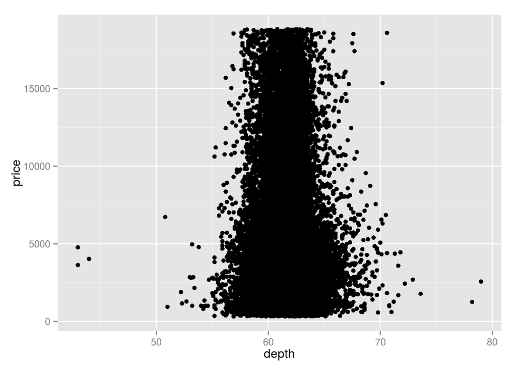

```r
ggplot(aes(x=depth, y=price), data = diamonds) +
  geom_point()
```

Yuck! Let’s prevent some of the overplotting so we might be able to see a trend.

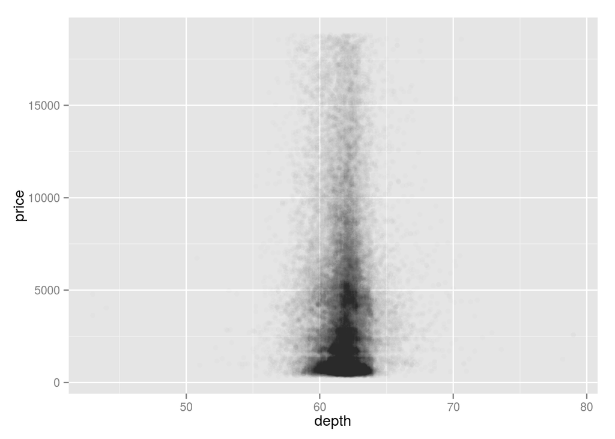

```r
ggplot(aes(x=depth, y=price), data = diamonds) +
  geom_point(alpha=1/100)
```

We can see from this plot that most diamonds have depth values between 60 and 64.

```r
cor.test(diamonds$depth, diamonds$price, method = 'pearson')
```

```
##
##  Pearson's product-moment correlation
##
## data:  diamonds$depth and diamonds$price
## t = -2.473, df = 53938, p-value = 0.0134
## alternative hypothesis: true correlation is not equal to 0
## 95 percent confidence interval:
##  -0.019084756 -0.002208537
## sample estimates:
##        cor
## -0.0106474
```

Now I plot price vs. carat.

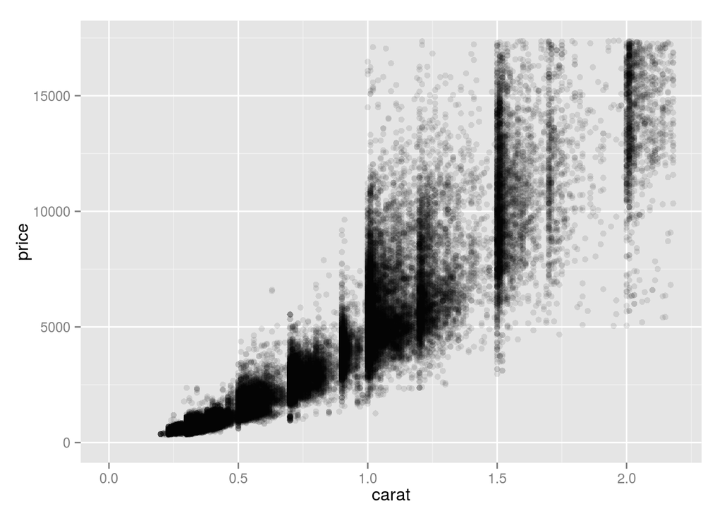

```r
ggplot(aes(x=carat, y=price), data = diamonds) +
  geom_point(alpha=1/10) +
  xlim(0, quantile(diamonds$carat, 0.99)) +
  ylim(0, quantile(diamonds$price, 0.99))
```

I will create a new variable to represent the volume of the diamonds. This variable is calculated by multiplying the x, y, and z variables. Then I plot volume vs. price.

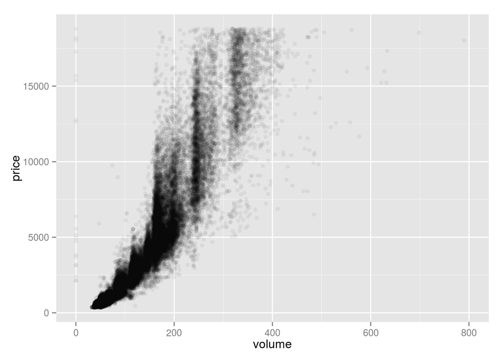

```r
diamonds$volume = diamonds$x * diamonds$y * diamonds$z

ggplot(aes(x=volume, y=price), data = diamonds) +
  geom_point(alpha=1/20) +
  xlim(0, 800)
```

Let’s find the correlation between price and diamonds with a volume between 0 and 800.

```r
custom_volume = subset(diamonds, diamonds$volume > 0)
custom_volume = subset(custom_volume, custom_volume$volume <= 800)
cor.test(custom_volume$volume, custom_volume$price, method = 'pearson')
```

```
##
##  Pearson's product-moment correlation
##
## data:  custom_volume$volume and custom_volume$price
## t = 559.1912, df = 53915, p-value < 2.2e-16
## alternative hypothesis: true correlation is not equal to 0
## 95 percent confidence interval:
##  0.9222944 0.9247772
## sample estimates:
##       cor
## 0.9235455
```

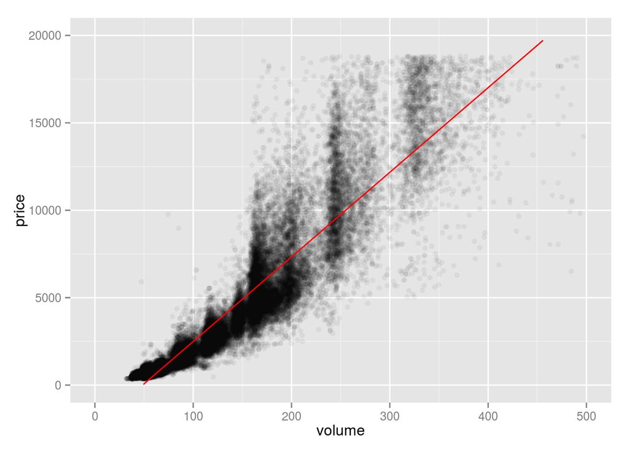

```r
ggplot(aes(x=volume, y=price), data = custom_volume) +
  geom_point(alpha=1/20) +
  xlim(0, 500) +
  ylim(0, 20000) +
  geom_smooth(method = 'lm', color='red')
```

This doesn’t look like a good fit at all. The linear model line entirely misses what may be an actual linear relationship for prices under 8000 and volumes under 180. Let’s zoom in further to see if this data is approximately linear in that range.

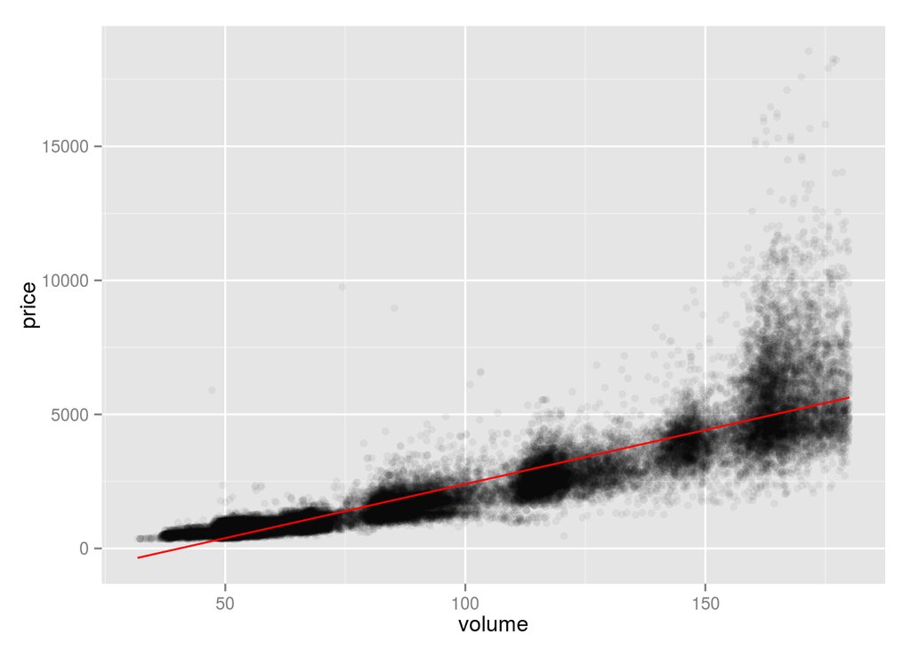

```r
tiny = subset(diamonds, diamonds$volume > 30)
tiny = subset(tiny, tiny$volume <= 180)

ggplot(aes(x=volume, y=price), data = tiny) +
  geom_point(alpha=1/20) +
  geom_smooth(method = 'lm', color='red')
```

```r
library(dplyr)
diamonds_by_clarity <- group_by(diamonds, clarity)
diamonds_mp_by_clarity <- summarise(diamonds_by_clarity, mean_price = mean(price))

diamonds_by_color <- group_by(diamonds, color)
diamonds_mp_by_color <- summarise(diamonds_by_color, mean_price = mean(price))

head(diamonds_mp_by_clarity)
```

```
## Source: local data frame [6 x 2]
##
##   clarity mean_price
## 1      I1   3924.169
## 2     SI2   5063.029
## 3     SI1   3996.001
## 4     VS2   3924.989
## 5     VS1   3839.455
## 6    VVS2   3283.737
```